# Broken Social Contract

Study 3: Analysis Report

# Background

The purpose of Study 3 was to test if the relationship between a broken social contract is and political discontent is a causal relationship. To that end, we applied for the Time-sharing Experiments for the Social Studies ([TESS](https://tessexperiments.org/)) federal research grant. After a rigorous peer review process and collaborative study design, we partnered with [NORC](https://www.norc.org/) to access the nationally representative [AmeriSpeak](https://amerispeak.norc.org/) participant pool.  
In a three-cell experimental design, participants listed, in open-text form, five values that they believe guide the U.S. on paper (i.e., the Constitution). Then, they indicated which of the values they listed is most important to the U.S. on paper.  
This value was then embedded into the experimental manipulation. Participants were randomly assigned to one of three conditions: (1) the *promise kept* condition; (2) the *promise broken* condition; and (3) the *control* condition. Those in the *promise kept* condition wrote 2-3 sentences about the ways in which the U.S. is living up to its promise of that value. Participants in the *promise broken* condition wrote 2-3 sentences about the ways in which the U.S. is NOT living up to its promise of that value. Participants in the *control* condition provided a definition of that value.  
Then, they completed five randomly-ordered DV’s: (1) anti-establishment sentiment; (2) American pride; (3) trust in government; (4) satisfaction with American democracy; and (5) support for radical change.

# Hypotheses

1. Participants in the *promise broken* condition will report **higher anti-establishment sentiment** than participants in the *promise kept* condition.
2. Participants in the *promise broken* condition will report **lower trust in government** than participants in the *promise kept* condition.
3. Participants in the *promise broken* condition will report **higher support for radical change** than participants in the *promise kept* condition.  
   We did not have specific hypotheses about the control condition. This is because it wasn’t clear, a-priori, whether the baseline of participants is that the promise of the social contract is broken, or whether it is that the promise is kept. Therefore, any analysis that includes all three conditions is exploratory. Any difference that emerges between one of the experimental conditions and the control condition helps us determine the direction in which the manipulation operates: does it increase or decrease baseline political discontent?  
   Additionally, we did not have an a-priori hypotheses about the effect of condition on American pride and satisfaction with American democracy. These two DV’s were added in consultation with TESS, on top of the three DV’s that we suggested after Studies 1 and 2. Therefore, any analysis we conduct with these DV’s is exploratory.

# Data collection

Data collection was conducted by NORC between 11/18/2024 and 12/4/2024. After data collection, we manually excluded participants who did not comply with the manipulation instructions at all. Elgibility is reported below:

```r
eligible_N <- df_bsc %>%
  group_by(exclude) %>%
  summarise(N = n()) %>%
  ungroup() %>%
  filter(exclude == 0) %>%
  select(N) %>%
  unname() %>%
  unlist()

df_bsc %>%
  group_by(exclude) %>%
  summarise(N = n()) %>%
  ungroup() %>%
  mutate(Perc = round(100*(N/sum(N)),2)) %>%
  ungroup() %>%
  kbl() %>%
  kable_styling(bootstrap_options = "hover",
                full_width = F,
                position = "left")
```

| exclude | N | Perc |
| --- | --- | --- |
| 0 | 1778 | 97.53 |
| 1 | 45 | 2.47 |

Great. That leaves us with 1778 eligible participants.

# Demographics

## Race and ethnicity

```r
df_bsc_elg %>%
  group_by(RACETHNICITY) %>%
  summarise(N = n()) %>%
  ungroup() %>%
  mutate(Perc = round(100*(N/sum(N)),2)) %>%
  ungroup() %>%
  kbl() %>%
  kable_styling(bootstrap_options = "hover",
                full_width = F,
                position = "left")
```

| RACETHNICITY | N | Perc |
| --- | --- | --- |
| asian/non-hisp | 65 | 3.66 |
| black/non-hisp | 200 | 11.25 |
| hisp | 358 | 20.13 |
| multi/non-hisp | 61 | 3.43 |
| other/non-hisp | 26 | 1.46 |
| white/non-hisp | 1068 | 60.07 |

## Gender

```r
df_bsc_elg %>%
  group_by(GENDER) %>%
  summarise(N = n()) %>%
  ungroup() %>%
  mutate(Perc = round(100*(N/sum(N)),2)) %>%
  ungroup() %>%
  kbl() %>%
  kable_styling(bootstrap_options = "hover",
                full_width = F,
                position = "left")
```

| GENDER | N | Perc |
| --- | --- | --- |
| female | 903 | 50.79 |
| male | 875 | 49.21 |

## Age

```r
df_bsc_elg %>%
  summarise(age_mean = round(mean(AGE,na.rm = T),2),
            age_sd = round(sd(AGE,na.rm = T),2)) %>%
  kbl() %>%
  kable_styling(bootstrap_options = "hover",
                full_width = F,
                position = "left")
```

| age_mean | age_sd |
| --- | --- |
| 48.45 | 17.48 |

## Education

```r
df_bsc_elg %>%
  group_by(edu) %>%
  summarise(N = n()) %>%
  ungroup() %>%
  mutate(Perc = round(100*(N/sum(N)),2)) %>%
  ungroup() %>%
  kbl() %>%
  kable_styling(bootstrap_options = "hover",
                full_width = F,
                position = "left")
```

| edu | N | Perc |
| --- | --- | --- |
| less HS | 92 | 5.17 |
| HS | 327 | 18.39 |
| some coll | 727 | 40.89 |
| bachelors | 368 | 20.70 |
| masters | 264 | 14.85 |

## Income

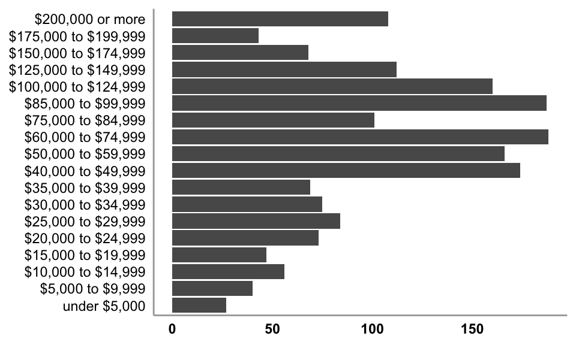

```r
income_med <- median(df_bsc_elg$income_num,na.rm = T)
all_incomes <- c("under $5,000",
                 "$5,000 to $9,999",
                 "$10,000 to $14,999",
                 "$15,000 to $19,999",
                 "$20,000 to $24,999",
                 "$25,000 to $29,999",
                 "$30,000 to $34,999",
                 "$35,000 to $39,999",
                 "$40,000 to $49,999",
                 "$50,000 to $59,999",
                 "$60,000 to $74,999",
                 "$75,000 to $84,999",
                 "$85,000 to $99,999",
                 "$100,000 to $124,999",
                 "$125,000 to $149,999",
                 "$150,000 to $174,999",
                 "$175,000 to $199,999",
                 "$200,000 or more")
income_med_char <- all_incomes[income_med]

df_bsc_elg %>%
  ggplot(aes(x = income)) +
  geom_bar() +
  theme(panel.grid.major = element_blank(),
        panel.grid.minor = element_blank(),
        panel.background = element_blank(),
        axis.ticks = element_blank(),
        axis.line = element_line(color = "grey66"),
        axis.text.y = element_text(color = "black"),
        axis.text.x = element_text(color = "black",
                                   face = "bold"),
        axis.title.x = element_blank(),
        axis.title.y = element_blank()) +
  coord_flip()
```

Median = $60,000 to $74,999

# Measures

## Value lists

Since its independence and onwards, the formation of the United States as a sovereign country was based on a number of values, all of which were enshrined in the constitution. This document has evolved since it was first written.  
When it comes to the PROMISE of the United States, what do you think are the values that this country stands for?  
Please list FIVE values.  
*Top 50 most mentioned:*

```r
df_bsc_elg %>%
  select(PID,val_1:val_5) %>%
  pivot_longer(-PID,
               names_to = "val_num",
               values_to = "value") %>%
  filter(value != "98") %>%
  filter(value != "") %>%
  filter(!is.na(value)) %>%
  mutate(value = str_to_lower(value)) %>%
  group_by(value) %>%
  summarise(N = n()) %>%
  ungroup() %>%
  mutate(Perc = round(100*(N/sum(N)),2)) %>%
  ungroup() %>%
  arrange(desc(N)) %>%
  slice(1:50) %>%
  dplyr::select(N,Perc,value) %>%
  kbl() %>%
  kable_styling(bootstrap_options = "hover",
                position = "left") %>%
  scroll_box(width = "100%", height = "400px")
```

| N | Perc | value |
| --- | --- | --- |
| 711 | 8.05 | freedom |
| 427 | 4.83 | equality |
| 357 | 4.04 | freedom of speech |
| 337 | 3.81 | liberty |
| 228 | 2.58 | justice |
| 225 | 2.55 | democracy |
| 220 | 2.49 | freedom of religion |
| 142 | 1.61 | independence |
| 134 | 1.52 | opportunity |
| 118 | 1.34 | pursuit of happiness |
| 95 | 1.08 | honesty |
| 94 | 1.06 | integrity |
| 79 | 0.89 | diversity |
| 77 | 0.87 | life |
| 76 | 0.86 | safety |
| 66 | 0.75 | family |
| 66 | 0.75 | free speech |
| 64 | 0.72 | right to bear arms |
| 60 | 0.68 | religious freedom |
| 59 | 0.67 | individualism |
| 59 | 0.67 | respect |
| 58 | 0.66 | fairness |
| 54 | 0.61 | money |
| 53 | 0.60 | unity |
| 48 | 0.54 | happiness |
| 47 | 0.53 | honor |
| 43 | 0.49 | prosperity |
| 42 | 0.48 | trust |
| 41 | 0.46 | love |
| 40 | 0.45 | justice for all |
| 39 | 0.44 | peace |
| 38 | 0.43 | equal rights |
| 37 | 0.42 | truth |
| 35 | 0.40 | loyalty |
| 32 | 0.36 | rights |
| 31 | 0.35 | rule of law |
| 30 | 0.34 | education |
| 30 | 0.34 | freedom of choice |
| 30 | 0.34 | god |
| 29 | 0.33 | right to vote |
| 27 | 0.31 | security |
| 26 | 0.29 | equal opportunity |
| 26 | 0.29 | religion |
| 25 | 0.28 | capitalism |
| 25 | 0.28 | protection |
| 24 | 0.27 | compassion |
| 24 | 0.27 | hard work |
| 22 | 0.25 | limited government |
| 22 | 0.25 | pride |
| 21 | 0.24 | equality for all |

## Top Values

Participants were then shown the values that they listed, and were asked, of these values, which one did they believe is most important to the U.S.’s promise.  
Top 50 most mentioned:

```r
df_bsc_elg %>%
  mutate(top_value_char = str_to_lower(top_value_char)) %>%
  group_by(top_value_char) %>%
  summarise(N = n()) %>%
  ungroup() %>%
  mutate(Perc = round(100*(N/sum(N)),2)) %>%
  ungroup() %>%
  arrange(desc(N)) %>%
  dplyr::select(N,Perc,top_value_char) %>%
  slice(1:50) %>%
  kbl() %>%
  kable_styling(bootstrap_options = "hover",
                position = "left") %>%
  scroll_box(width = "100%", height = "400px")
```

| N | Perc | top_value_char |
| --- | --- | --- |
| 431 | 24.24 | freedom |
| 93 | 5.23 | freedom of speech |
| 89 | 5.01 | democracy |
| 83 | 4.67 | liberty |
| 77 | 4.33 | equality |
| 39 | 2.19 | freedom of religion |
| 25 | 1.41 | independence |
| 22 | 1.24 | integrity |
| 22 | 1.24 | opportunity |
| 19 | 1.07 | honesty |
| 17 | 0.96 | god |
| 15 | 0.84 | pursuit of happiness |
| 14 | 0.79 | equal rights |
| 13 | 0.73 | free speech |
| 13 | 0.73 | life |
| 13 | 0.73 | money |
| 12 | 0.67 | equality for all |
| 11 | 0.62 | limited government |
| 10 | 0.56 | family |
| 10 | 0.56 | freedom of choice |
| 10 | 0.56 | justice |
| 10 | 0.56 | respect |
| 9 | 0.51 | economy |
| 9 | 0.51 | rights |
| 9 | 0.51 | rule of law |
| 8 | 0.45 | right to bear arms |
| 7 | 0.39 | freedom from oppression |
| 7 | 0.39 | love |
| 7 | 0.39 | safety |
| 6 | 0.34 | honor |
| 6 | 0.34 | prosperity |
| 6 | 0.34 | religious freedom |
| 6 | 0.34 | trust |
| 5 | 0.28 | capitalism |
| 5 | 0.28 | freedom for all |
| 5 | 0.28 | freedom from tyranny |
| 5 | 0.28 | freedom of speach |
| 5 | 0.28 | honest |
| 5 | 0.28 | individual rights |
| 5 | 0.28 | individualism |
| 5 | 0.28 | loyalty |
| 4 | 0.22 | checks and balances |
| 4 | 0.22 | democratic government |
| 4 | 0.22 | diversity |
| 4 | 0.22 | equity |
| 4 | 0.22 | fairness |
| 4 | 0.22 | justice for all |
| 4 | 0.22 | the pursuit of happiness |
| 4 | 0.22 | truth |
| 4 | 0.22 | unity |

## Manipulation responses

### Promise Kept Condition

In 2-3 sentences, please describe the ways in which the U.S. is living up to its promise of [TOP-VALUE].

```r
df_bsc_elg %>%
  filter(cond == "kept") %>%
  mutate(response = iconv(response,from =  "UTF-8", to = "ASCII", sub = "")) %>%
  rename(top_value = top_value_char) %>%
  select(PID,top_value,response) %>%
  kbl() %>%
  kable_styling(bootstrap_options = "hover",
                position = "left") %>%
  scroll_box(width = "100%", height = "400px")
```

### Promise Broken Condition

In 2-3 sentences, please describe the ways in which the U.S. is NOT living up to its promise of [TOP-VALUE].

```r
df_bsc_elg %>%
  filter(cond == "brkn") %>%
  mutate(response = iconv(response,from =  "UTF-8", to = "ASCII", sub = "")) %>%
  rename(top_value = top_value_char) %>%
  select(top_value,response) %>%
  kbl() %>%
  kable_styling(bootstrap_options = "hover",
                position = "left") %>%
  scroll_box(width = "100%", height = "400px")
```

### Control Condition

In 2-3 sentences, please define [TOP-VALUE].

```r
df_bsc_elg %>%
  filter(cond == "ctrl") %>%
  mutate(response = iconv(response,from =  "UTF-8", to = "ASCII", sub = "")) %>%
  rename(top_value = top_value_char) %>%
  select(top_value,response) %>%
  kbl() %>%
  kable_styling(bootstrap_options = "hover",
                position = "left") %>%
  scroll_box(width = "100%", height = "400px")
```

## Anti-Establishment Sentiment

To what extent do you agree or disagree with the following statements? (1 = *Strongly Disagree* to 7 = *Strongly Agree*)  
1. The US’s economy is rigged to advantage the rich and powerful  
2. Traditional politicians and parties don’t care about people like me  
3. Experts in this country don’t understand the lives of people like me  
4. Most of the time we can trust people in the government to do what is right [R]  
alpha = 0.7

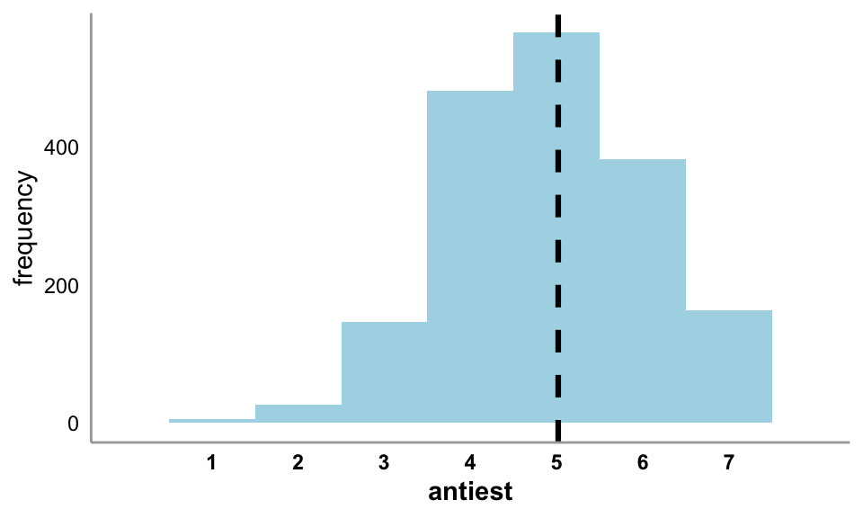

```r
df_bsc_elg %>%
  ggplot(aes(x = antiest)) +
  geom_histogram(fill = "lightblue",
                 color = NA,
                 binwidth = 1) +
  scale_x_continuous(breaks = seq(1,7,1),
                     limits = c(0,8)) +
  ylab("frequency") +
  geom_vline(xintercept = mean(df_bsc_elg$antiest,na.rm = T),
             color = "black",
             linetype = "dashed",
             size = 1.1) +
  theme(panel.grid.major = element_blank(),
        panel.grid.minor = element_blank(),
        panel.background = element_blank(),
        axis.ticks = element_blank(),
        axis.line = element_line(color = "grey66"),
        axis.text.y = element_text(color = "black"),
        axis.text.x = element_text(color = "black",
                                   face = "bold"),
        axis.title.x = element_text(color = "black",
                                   face = "bold"))
```

## Trust in government

To what extent do you trust the government in Washington, across parties and administrations, to do what is right? (1 = *Not at All* to 7 = *A Great Deal*)

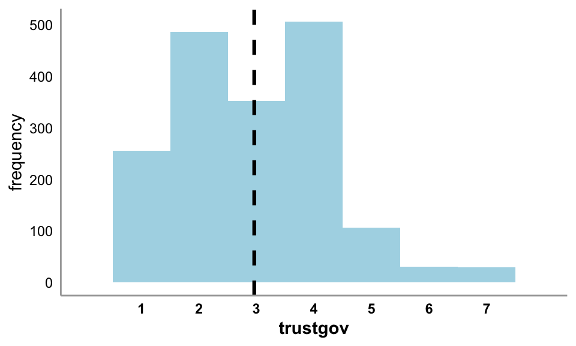

```r
df_bsc_elg %>%
  ggplot(aes(x = trustgov)) +
  geom_histogram(fill = "lightblue",
                 color = NA,
                 binwidth = 1) +
  scale_x_continuous(breaks = seq(1,7,1),
                     limits = c(0,8)) +
  ylab("frequency") +
  geom_vline(xintercept = mean(df_bsc_elg$trustgov,na.rm = T),
             color = "black",
             linetype = "dashed",
             size = 1.1) +
  theme(panel.grid.major = element_blank(),
        panel.grid.minor = element_blank(),
        panel.background = element_blank(),
        axis.ticks = element_blank(),
        axis.line = element_line(color = "grey66"),
        axis.text.y = element_text(color = "black"),
        axis.text.x = element_text(color = "black",
                                   face = "bold"),
        axis.title.x = element_text(color = "black",
                                   face = "bold"))
```

## Support for radical change

To what extent do you agree or disagree with the following statement? (1 = *Strongly Disagree* to 7 = *Strongly Agree*)  
The way this country works needs to be radically changed.

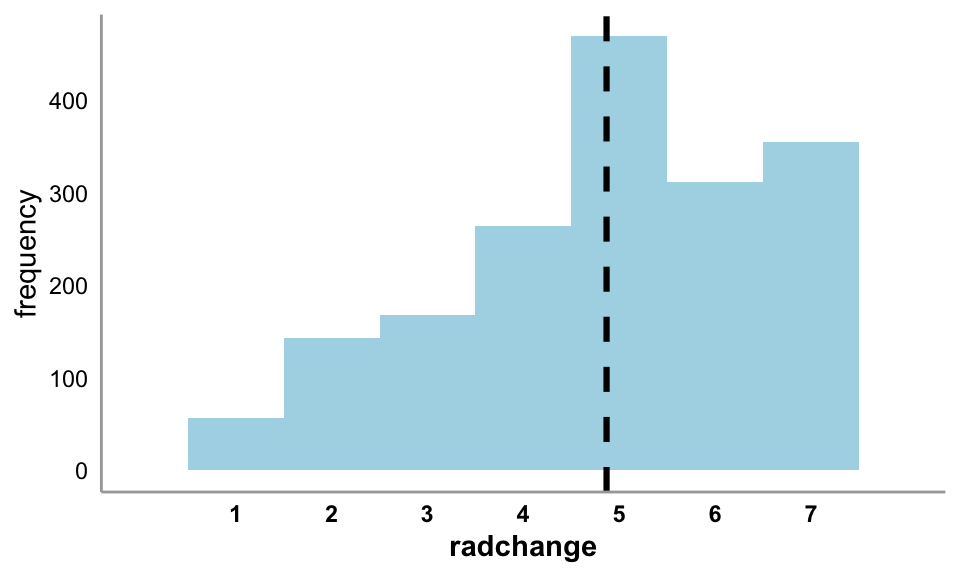

```r
df_bsc_elg %>%
  ggplot(aes(x = radchange)) +
  geom_histogram(fill = "lightblue",
                 color = NA,
                 binwidth = 1) +
  scale_x_continuous(breaks = seq(1,7,1),
                     limits = c(0,8)) +
  ylab("frequency") +
  geom_vline(xintercept = mean(df_bsc_elg$radchange,na.rm = T),
             color = "black",
             linetype = "dashed",
             size = 1.1) +
  theme(panel.grid.major = element_blank(),
        panel.grid.minor = element_blank(),
        panel.background = element_blank(),
        axis.ticks = element_blank(),
        axis.line = element_line(color = "grey66"),
        axis.text.y = element_text(color = "black"),
        axis.text.x = element_text(color = "black",
                                   face = "bold"),
        axis.title.x = element_text(color = "black",
                                   face = "bold"))
```

## American Pride

How proud are you to be an American? (1 = *Not at all Proud* to 5 = *Extremely Proud*)

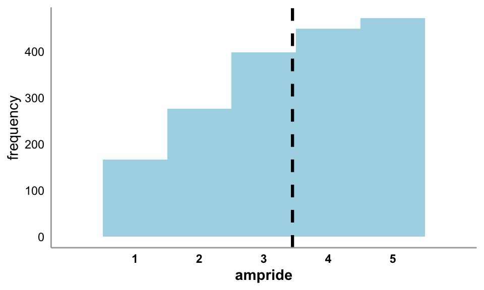

```r
df_bsc_elg %>%
  ggplot(aes(x = ampride)) +
  geom_histogram(fill = "lightblue",
                 color = NA,
                 binwidth = 1) +
  scale_x_continuous(breaks = seq(1,5,1),
                     limits = c(0,6)) +
  ylab("frequency") +
  geom_vline(xintercept = mean(df_bsc_elg$ampride,na.rm = T),
             color = "black",
             linetype = "dashed",
             size = 1.1) +
  theme(panel.grid.major = element_blank(),
        panel.grid.minor = element_blank(),
        panel.background = element_blank(),
        axis.ticks = element_blank(),
        axis.line = element_line(color = "grey66"),
        axis.text.y = element_text(color = "black"),
        axis.text.x = element_text(color = "black",
                                   face = "bold"),
        axis.title.x = element_text(color = "black",
                                   face = "bold"))
```

## Satisfaction with American democracy

How satisfied are you with the way democracy is working in the United States? (1 = *Extremely Dissatisfied* to 7 = *Extremely Satisfied*)

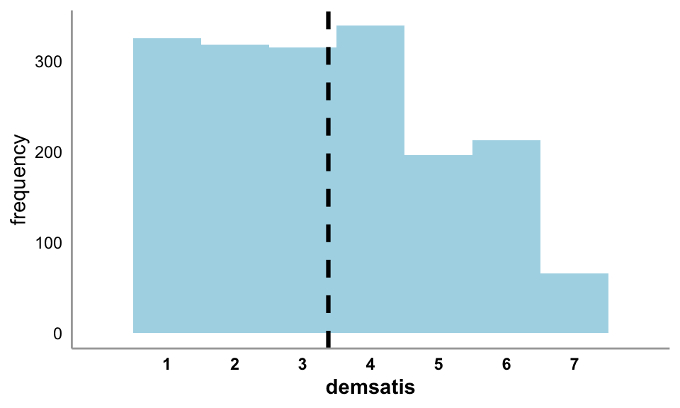

```r
df_bsc_elg %>%
  ggplot(aes(x = demsatis)) +
  geom_histogram(fill = "lightblue",
                 color = NA,
                 binwidth = 1) +
  scale_x_continuous(breaks = seq(1,7,1),
                     limits = c(0,8)) +
  ylab("frequency") +
  geom_vline(xintercept = mean(df_bsc_elg$demsatis,na.rm = T),
             color = "black",
             linetype = "dashed",
             size = 1.1) +
  theme(panel.grid.major = element_blank(),
        panel.grid.minor = element_blank(),
        panel.background = element_blank(),
        axis.ticks = element_blank(),
        axis.line = element_line(color = "grey66"),
        axis.text.y = element_text(color = "black"),
        axis.text.x = element_text(color = "black",
                                   face = "bold"),
        axis.title.x = element_text(color = "black",
                                   face = "bold"))
```

# Analysis

## Confirmatory Analyses

First, I will conduct analyses that directly test our hypotheses:  
1. Participants in the *promise broken* condition will report **higher anti-establishment sentiment** than participants in the *promise kept* condition.  
2. Participants in the *promise broken* condition will report **lower trust in government** than participants in the *promise kept* condition.  
3. Participants in the *promise broken* condition will report **higher support for radical change** than participants in the *promise kept* condition.  
Therefore, these analyses will only compare those two conditions without adjusting for multiple comparisons.  
Then, I will conduct exploratory analyses to examine the control condition as well and the two other DV’s.

### Anti-establishment sentiment

```r
df_bsc_elg %>%
  filter(cond != "ctrl") %>%
  group_by(cond) %>%
  summarise(N = n(),
            mean = mean(antiest,na.rm = T),
            sd = sd(antiest,na.rm = T)) %>%
  ungroup() %>%
  kbl() %>%
  kable_styling(bootstrap_options = "hover",
                full_width = F,
                position = "left")
```

| cond | N | mean | sd |
| --- | --- | --- | --- |
| brkn | 591 | 5.184322 | 1.14255 |
| kept | 574 | 4.926883 | 1.09532 |

Two-sample t-test:

```r
m1 <- rstatix::t_test(antiest ~ cond,data = df_bsc_elg %>% filter(cond != "ctrl"),paired = F,detailed = T)
m2 <- rstatix::cohens_d(antiest ~ cond,data = df_bsc_elg %>% filter(cond != "ctrl"),paired = F)

d = round(m2$effsize,2)

m1 %>%
  select(statistic,df,p,conf.low,conf.high) %>%
  mutate(d = d) %>%
  kbl() %>%
  kable_styling(bootstrap_options = "hover",
                full_width = F,
                position = "left")
```

| statistic | df | p | conf.low | conf.high | d |
| --- | --- | --- | --- | --- | --- |
| 3.919688 | 1158.896 | 9.39e-05 | 0.1285772 | 0.3863015 | 0.23 |

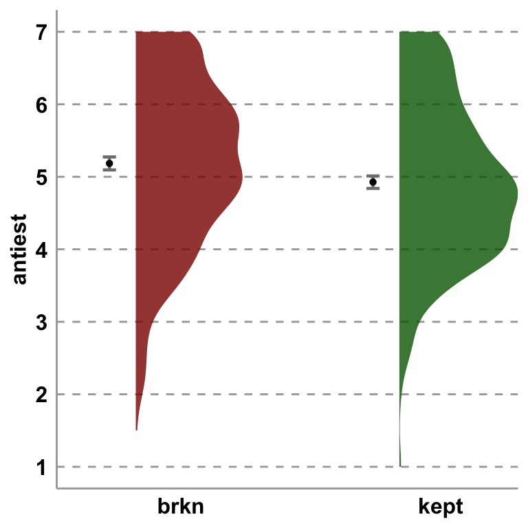

### Trust in government

```r
df_bsc_elg %>%
  filter(cond != "ctrl") %>%
  group_by(cond) %>%
  summarise(N = n(),
            mean = mean(trustgov,na.rm = T),
            sd = sd(trustgov,na.rm = T)) %>%
  ungroup() %>%
  kbl() %>%
  kable_styling(bootstrap_options = "hover",
                full_width = F,
                position = "left")
```

| cond | N | mean | sd |
| --- | --- | --- | --- |
| brkn | 591 | 2.852041 | 1.336251 |
| kept | 574 | 3.012281 | 1.355140 |

Two-sample t-test:

```r
m1 <- rstatix::t_test(trustgov ~ cond,data = df_bsc_elg %>% filter(cond != "ctrl"),paired = F,detailed = T)
m2 <- rstatix::cohens_d(trustgov ~ cond,data = df_bsc_elg %>% filter(cond != "ctrl"),paired = F)

d = round(m2$effsize,2)

m1 %>%
  select(statistic,df,p,conf.low,conf.high) %>%
  mutate(d = d) %>%
  kbl() %>%
  kable_styling(bootstrap_options = "hover",
                full_width = F,
                position = "left")
```

| statistic | df | p | conf.low | conf.high | d |
| --- | --- | --- | --- | --- | --- |
| -2.025525 | 1153.648 | 0.043 | -0.3154561 | -0.0050237 | -0.12 |

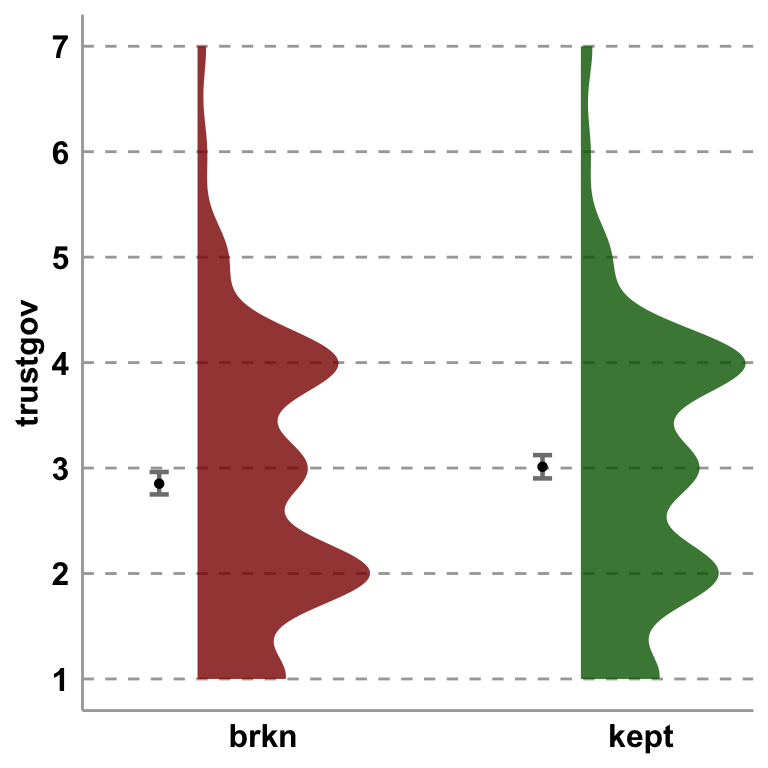

### Support for radical change

```r
df_bsc_elg %>%
  filter(cond != "ctrl") %>%
  group_by(cond) %>%
  summarise(N = n(),
            mean = mean(radchange,na.rm = T),
            sd = sd(radchange,na.rm = T)) %>%
  ungroup() %>%
  kbl() %>%
  kable_styling(bootstrap_options = "hover",
                full_width = F,
                position = "left")
```

| cond | N | mean | sd |
| --- | --- | --- | --- |
| brkn | 591 | 5.062925 | 1.608470 |
| kept | 574 | 4.836555 | 1.677208 |

Two-sample t-test:

```r
m1 <- rstatix::t_test(radchange ~ cond,data = df_bsc_elg %>% filter(cond != "ctrl"),paired = F,detailed = T)
m2 <- rstatix::cohens_d(radchange ~ cond,data = df_bsc_elg %>% filter(cond != "ctrl"),paired = F)

d = round(m2$effsize,2)

m1 %>%
  select(statistic,df,p,conf.low,conf.high) %>%
  mutate(d = d) %>%
  kbl() %>%
  kable_styling(bootstrap_options = "hover",
                full_width = F,
                position = "left")
```

| statistic | df | p | conf.low | conf.high | d |
| --- | --- | --- | --- | --- | --- |
| 2.341842 | 1148.597 | 0.0194 | 0.0367136 | 0.416026 | 0.14 |

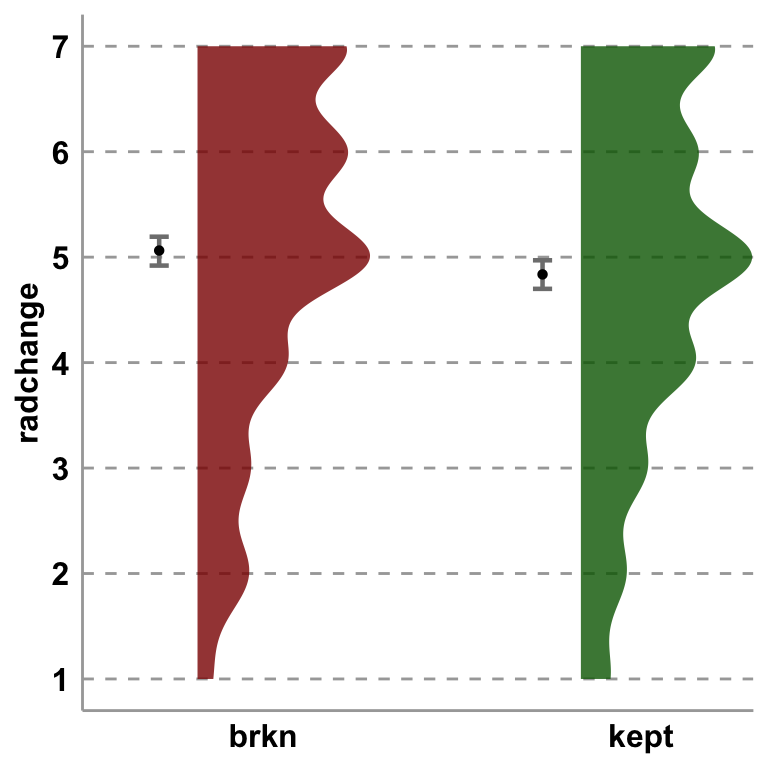

## Exploratory Analyses

### Anti-establishment sentiment

```r
df_bsc_elg %>%
  group_by(cond) %>%
  summarise(N = n(),
            mean = mean(antiest,na.rm = T),
            sd = sd(antiest,na.rm = T)) %>%
  ungroup() %>%
  kbl() %>%
  kable_styling(bootstrap_options = "hover",
                full_width = F,
                position = "left")
```

| cond | N | mean | sd |
| --- | --- | --- | --- |
| brkn | 591 | 5.184322 | 1.142550 |
| ctrl | 613 | 4.940087 | 1.082434 |
| kept | 574 | 4.926883 | 1.095320 |

**One-way ANOVA Omnibus Effect:**  
*F*(2, 1770) = 10.11, *p* < .001, $\eta^2_p$ = .01  
**Tukey-HSD Post-Hoc Comparisons:** (adjusting for multiple comparisons)

|  | diff | lwr | upr | p adj |
| --- | --- | --- | --- | --- |
| ctrl-brkn | -0.2442349 | -0.3940392 | -0.0944306 | 0.0003987 |
| kept-brkn | -0.2574394 | -0.4098607 | -0.1050181 | 0.0002281 |
| kept-ctrl | -0.0132045 | -0.1642724 | 0.1378634 | 0.9770924 |

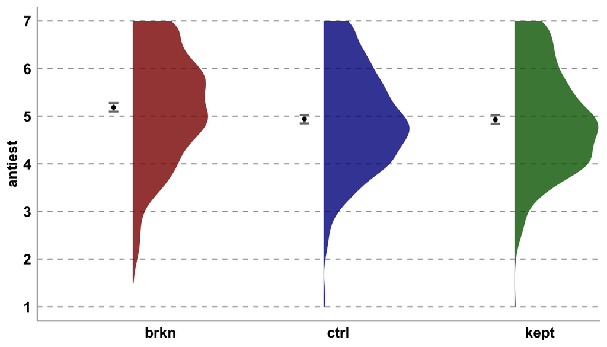

### Trust in Government

```r
df_bsc_elg %>%
  group_by(cond) %>%
  summarise(N = n(),
            mean = mean(trustgov,na.rm = T),
            sd = sd(trustgov,na.rm = T)) %>%
  ungroup() %>%
  kbl() %>%
  kable_styling(bootstrap_options = "hover",
                full_width = F,
                position = "left")
```

| cond | N | mean | sd |
| --- | --- | --- | --- |
| brkn | 591 | 2.852041 | 1.336251 |
| ctrl | 613 | 3.018062 | 1.333279 |
| kept | 574 | 3.012281 | 1.355140 |

**One-way ANOVA Omnibus Effect:**  
*F*(2, 1764) = 2.91, *p* = .055, $\eta^2_p$ < .01  
**Tukey-HSD Post-Hoc Comparisons:** (adjusting for multiple comparisons)

|  | diff | lwr | upr | p adj |
| --- | --- | --- | --- | --- |
| ctrl-brkn | 0.1660216 | -0.0158910 | 0.3479342 | 0.0820727 |
| kept-brkn | 0.1602399 | -0.0247045 | 0.3451843 | 0.1048161 |
| kept-ctrl | -0.0057817 | -0.1891498 | 0.1775864 | 0.9969887 |

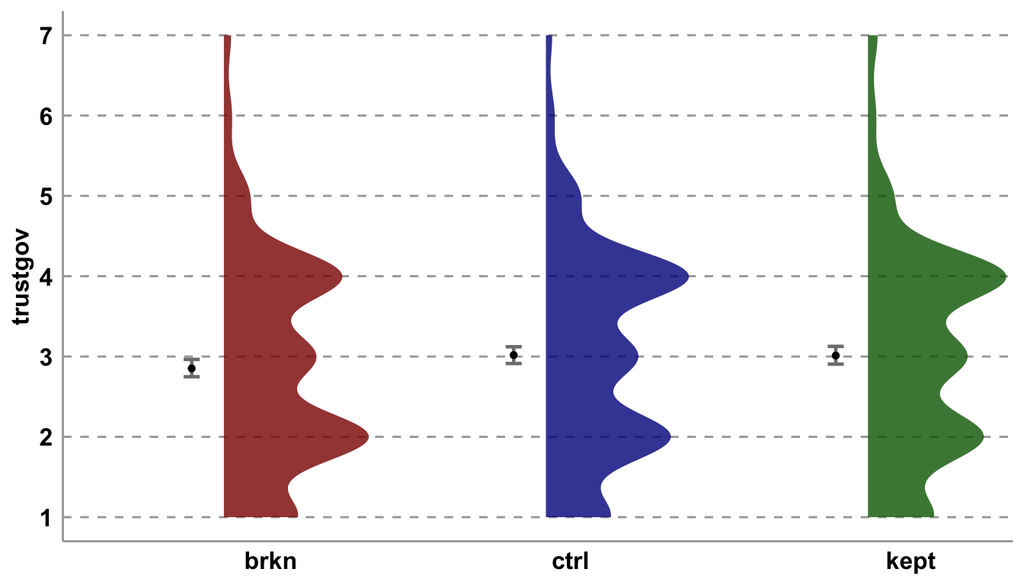

### Support for radical change

```r
df_bsc_elg %>%
  group_by(cond) %>%
  summarise(N = n(),
            mean = mean(radchange,na.rm = T),
            sd = sd(radchange,na.rm = T)) %>%
  ungroup() %>%
  kbl() %>%
  kable_styling(bootstrap_options = "hover",
                full_width = F,
                position = "left")
```

| cond | N | mean | sd |
| --- | --- | --- | --- |
| brkn | 591 | 5.062925 | 1.608470 |
| ctrl | 613 | 4.707038 | 1.659824 |
| kept | 574 | 4.836555 | 1.677208 |

**One-way ANOVA Omnibus Effect:**  
*F*(2, 1765) = 7.13, *p* < .001, $\eta^2_p$ < .01  
**Tukey-HSD Post-Hoc Comparisons:** (adjusting for multiple comparisons)

|  | diff | lwr | upr | p adj |
| --- | --- | --- | --- | --- |
| ctrl-brkn | -0.3558875 | -0.5792878 | -0.1324873 | 0.0005635 |
| kept-brkn | -0.2263698 | -0.4537775 | 0.0010379 | 0.0513667 |
| kept-ctrl | 0.1295177 | -0.0957752 | 0.3548106 | 0.3685290 |

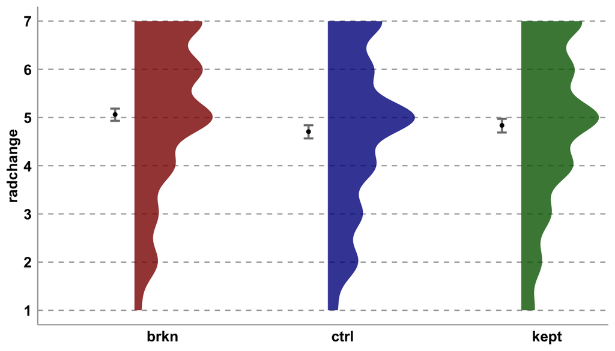

### American pride

```r
df_bsc_elg %>%
  group_by(cond) %>%
  summarise(N = n(),
            mean = mean(ampride,na.rm = T),
            sd = sd(ampride,na.rm = T)) %>%
  ungroup() %>%
  kbl() %>%
  kable_styling(bootstrap_options = "hover",
                full_width = F,
                position = "left")
```

| cond | N | mean | sd |
| --- | --- | --- | --- |
| brkn | 591 | 3.417377 | 1.304196 |
| ctrl | 613 | 3.453048 | 1.269347 |
| kept | 574 | 3.461403 | 1.300028 |

**One-way ANOVA Omnibus Effect:**  
*F*(2, 1761) = 0.19, *p* = .826, $\eta^2_p$ < .01  
**Tukey-HSD Post-Hoc Comparisons:** (adjusting for multiple comparisons)

|  | diff | lwr | upr | p adj |
| --- | --- | --- | --- | --- |
| ctrl-brkn | 0.0356713 | -0.1396235 | 0.2109661 | 0.8820131 |
| kept-brkn | 0.0440270 | -0.1340428 | 0.2220969 | 0.8308621 |
| kept-ctrl | 0.0083557 | -0.1682630 | 0.1849744 | 0.9932336 |

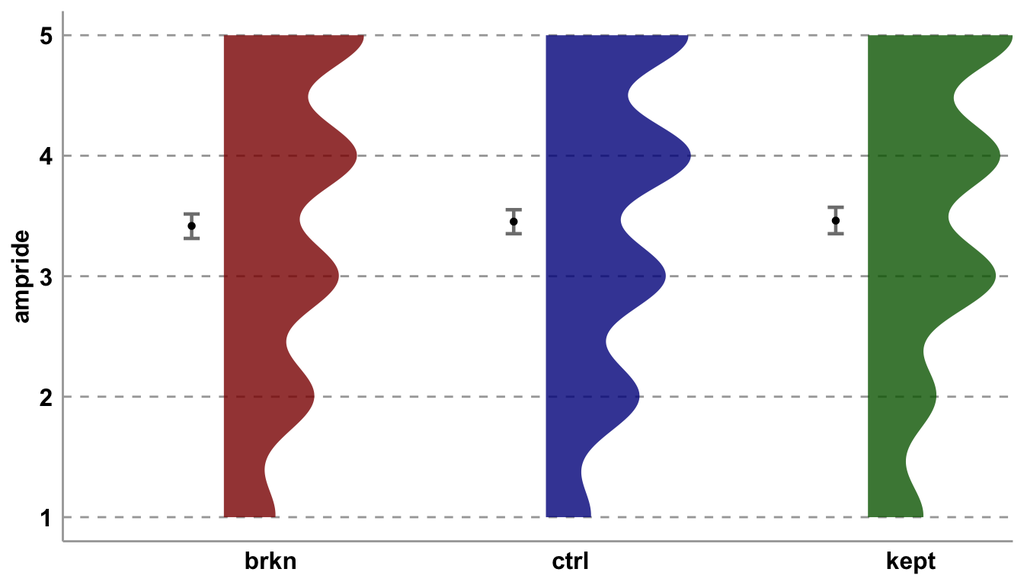

### Satisfaction with American democracy

```r
df_bsc_elg %>%
  group_by(cond) %>%
  summarise(N = n(),
            mean = mean(demsatis,na.rm = T),
            sd = sd(demsatis,na.rm = T)) %>%
  ungroup() %>%
  kbl() %>%
  kable_styling(bootstrap_options = "hover",
                full_width = F,
                position = "left")
```

| cond | N | mean | sd |
| --- | --- | --- | --- |
| brkn | 591 | 3.254237 | 1.735412 |
| ctrl | 613 | 3.415435 | 1.776998 |
| kept | 574 | 3.458988 | 1.752264 |

**One-way ANOVA Omnibus Effect:**  
*F*(2, 1769) = 2.21, *p* = .110, $\eta^2_p$ < .01  
**Tukey-HSD Post-Hoc Comparisons:** (adjusting for multiple comparisons)

|  | diff | lwr | upr | p adj |
| --- | --- | --- | --- | --- |
| ctrl-brkn | 0.1611979 | -0.0766393 | 0.3990350 | 0.2502706 |
| kept-brkn | 0.2047505 | -0.0367351 | 0.4462361 | 0.1152253 |
| kept-ctrl | 0.0435526 | -0.1960698 | 0.2831751 | 0.9046851 |

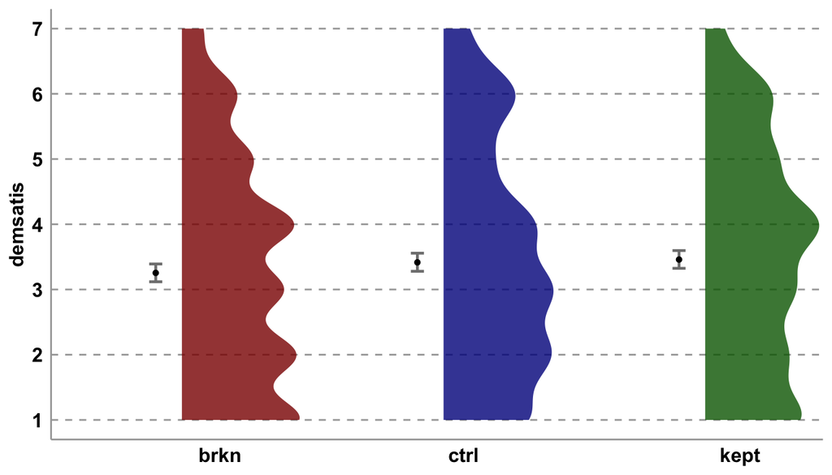